# Did Jean-Auguste-Dominique Ingres use less saturated values than Jacques Louis David in his historical paintings?

03 January 2017

# Context:

In 1797, Jean-Auguste-Dominique Ingres travelled to Paris to study in the studio of Jacques Louis David. Ingres noted that one should:

> “never use bright colours […] they are anti-historic. It is better to fall into gray than to into bright colours.”

Therefore, I wondered if there was a statistically significant difference between the saturation values used by Ingres and David.

# Hypotheses

Null Hypothesis: There is no statistically significant difference between the saturation values used by Ingres and David (95% confidence interval)

Alternative Hypothesis: There is a statistically significant difference between the saturation values used by Ingres and David as a result of a ‘real’ effect

# Load Data

```r
setwd("D:/R projects/Web Gallery of Art/Data")

web_gal <- read.csv('catalog_1.csv',sep=';',stringsAsFactors=F)
```

# Exploration

Before delving into the research question, let’s explore the dataset

```r
str(web_gal)
```

```
## 'data.frame':    44307 obs. of  11 variables:
##  $ AUTHOR   : chr  "AACHEN, Hans von" "AACHEN, Hans von" "AACHEN, Hans von" "AACHEN, Hans von" ...
##  $ BORN.DIED: chr  "(b. 1552, Köln, d. 1615, Praha)" "(b. 1552, Köln, d. 1615, Praha)" "(b. 1552, Köln, d. 1615, Praha)" "(b. 1552, Köln, d. 1615, Praha)" ...
##  $ TITLE    : chr  "Allegory" "Bacchus, Ceres and Cupid" "Joking Couple" "Portrait of Emperor Rudolf II" ...
##  $ DATE     : chr  "1598" "-" "-" "1590s" ...
##  $ TECHNIQUE: chr  "Oil on copper, 56 x 47 cm" "Oil on canvas, 163 x 113 cm" "Copperplate, 25 x 20 cm" "Oil on canvas, 60 x 48 cm" ...
##  $ LOCATION : chr  "Alte Pinakothek, Munich" "Kunsthistorisches Museum, Vienna" "Kunsthistorisches Museum, Vienna" "Kunsthistorisches Museum, Vienna" ...
##  $ URL      : chr  "https://www.wga.hu/html/a/aachen/allegory.html" "https://www.wga.hu/html/a/aachen/bacchus.html" "https://www.wga.hu/html/a/aachen/j_couple.html" "https://www.wga.hu/html/a/aachen/rudolf2.html" ...
##  $ FORM     : chr  "painting" "painting" "painting" "painting" ...
##  $ TYPE     : chr  "mythological" "mythological" "genre" "portrait" ...
##  $ SCHOOL   : chr  "German" "German" "German" "German" ...
##  $ TIMEFRAME: chr  "1601-1650" "1601-1650" "1601-1650" "1601-1650" ...
```

The database is missing the URLs to the paintings. In order to analyse the saturation values, these will have to be added.

```r
web_gal$IMAGE_URL <- gsub("/html/", "/art/", web_gal$URL)
web_gal$IMAGE_URL <- gsub(".html", ".jpg", web_gal$IMAGE_URL)
web_gal$IMAGE_URL[1:5]
```

```
## [1] "https://www.wga.hu/art/a/aachen/allegory.jpg"
## [2] "https://www.wga.hu/art/a/aachen/bacchus.jpg"
## [3] "https://www.wga.hu/art/a/aachen/j_couple.jpg"
## [4] "https://www.wga.hu/art/a/aachen/rudolf2.jpg"
## [5] "https://www.wga.hu/art/a/aachen/selfport.jpg"
```

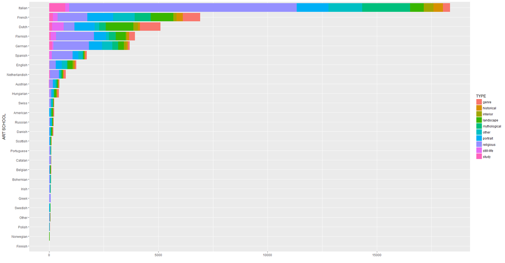

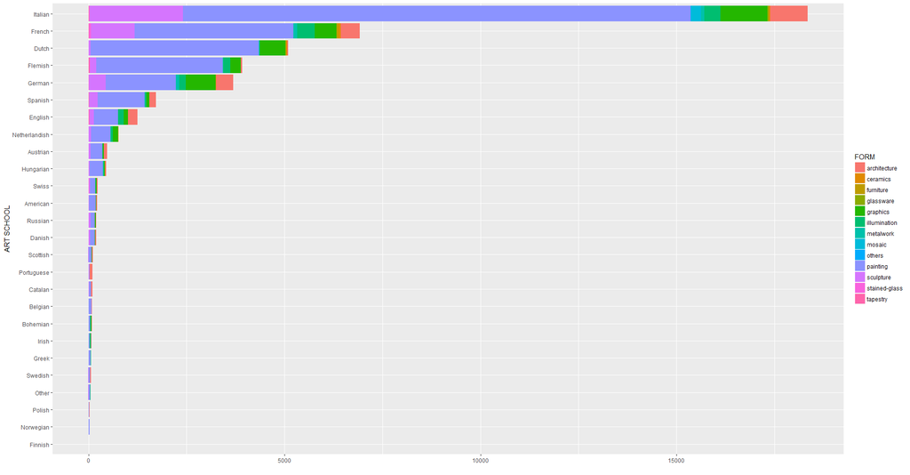

```r
web_gal$SCHOOL <- as.factor(web_gal$SCHOOL)
web_gal$TYPE <- as.factor(web_gal$TYPE)
web_gal$FORM <- as.factor(web_gal$FORM)

type <- ggplot(data = web_gal, aes(x = reorder(web_gal$SCHOOL, web_gal$SCHOOL, length), fill = TYPE)) + geom_bar(stat = "count") + coord_flip() + ylab('') + xlab("ART SCHOOL")

form <- ggplot(data = web_gal, aes(x = reorder(web_gal$SCHOOL, web_gal$SCHOOL, length), fill = FORM)) + geom_bar(stat = "count") + coord_flip() + ylab('') + xlab("ART SCHOOL")

grid.arrange(type, form, ncol=2)
```

As probably expected, the large majority of paintings in the database are from the Italian School, with religious being the most popular Type. Furthermore, ‘painting’ is the most popular Form.

Now to see the Date distribution of the database.

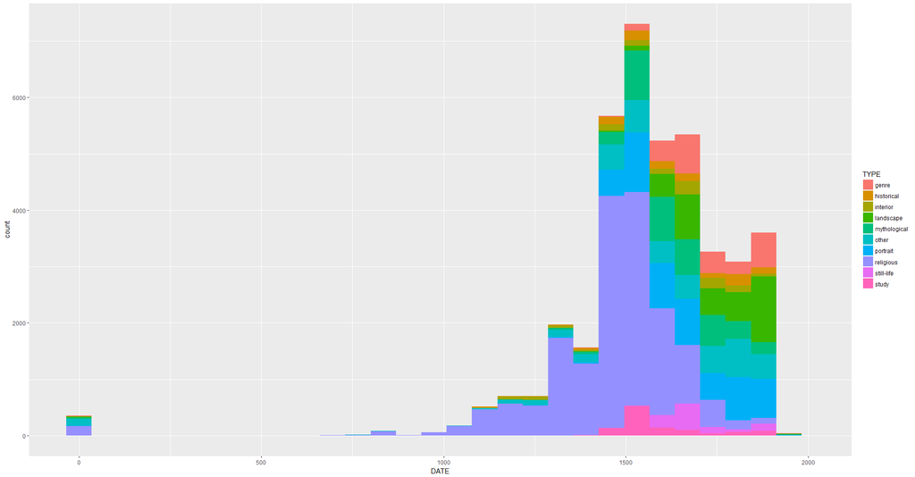

```r
web_gal$DATE <- gsub("[^0-9]", "", web_gal$DATE)
web_gal$DATE <- substr(web_gal$DATE, start = 1, stop = 4)

web_gal$DATE <- as.numeric(web_gal$DATE)

ggplot(data = web_gal, aes(x = DATE, fill = TYPE)) +
    geom_histogram() + scale_x_continuous(limits = c(min(web_gal$DATE), 2017))
```

More analysis could be done regarding Italian paintings, however that will have to be another project.

# Ingres and David comparison

For now, let’s subset the paintings by Ingres and David.

```r
dav_ing <- web_gal[web_gal$AUTHOR == "DAVID, Jacques-Louis" | web_gal$AUTHOR == "INGRES, Jean-Auguste-Dominique" & web_gal$FORM == "painting" & !web_gal$TYPE == "other",]
```

Before downloading the images (using the previously created Image URL), the title of the paintings are extracted, and used to name the file.

```r
title <- dav_ing$TITLE
url <- dav_ing$IMAGE_URL

for (i in 1:length(url)) {
  try(download.file(url[i], destfile= paste("D:/R projects/Web Gallery of Art/Artworks/", title[i], ".jpg", sep = ""), mode="wb"))
  Sys.sleep(2)
}
```

Downloaded images:

[figure not shown]

Read each painting and create list containing the Red, Green, and Blue values of each pixel that makes the painting.

```r
downloaded_paintings <- list.files(path = "D:/R projects/Web Gallery of Art/Artworks/", pattern="\\.jpg$")

paintings_list <- list()

for (i in 1:length(downloaded_paintings)) {
  paintings <- readJPEG(paste("D:/R projects/Web Gallery of Art/Artworks/", downloaded_paintings[i], sep=""), native = FALSE)
  paintings_list[[i]] <- paintings
}
```

Convert Red, Green, Blue (RGB) values to Hue, Saturation, and Value (HSV). This is done as HSV is the color model that comes closest to mimicking how humans perceive color (https://www.iteea.org/File.aspx?id=86467&v=1beee30d)

```r
paintings_HSV <- lapply(paintings_list, function(paintings_list) apply(paintings_list, c(1,2), RGB2HSV))
```

In order to identify who the painting is by, the AUTHOR is attached to the name attribute.

```r
downloaded_paintings_gsub <- gsub("\\.jpg$","", list.files(path = "D:/R projects/Web Gallery of Art/Artworks/", pattern="\\.jpg$"))

dav_ing <- dav_ing[dav_ing$TITLE %in% downloaded_paintings_gsub,]
dav_ing <- dav_ing[!duplicated(dav_ing$TITLE),]
dav_ing$AUTHOR <- as.factor(dav_ing$AUTHOR)

names(paintings_HSV) <- dav_ing$AUTHOR
```

Before looking at Saturation independently, Hue and Saturation will be explored. To do this, the mean Hue and Saturation of each painting will be extracted.

```r
paintings_HSV_mean <- lapply(paintings_HSV, function(paintings_HSV) apply(paintings_HSV, 1, mean))

paintings_HSV_mean_hue <- unlist(lapply(paintings_HSV_mean, "[", 1))
paintings_HSV_mean_sat <- unlist(lapply(paintings_HSV_mean, "[", 2))
```

Bind HSV values, with information about Artist.

```r
dav_ing_subset_df <- as.data.frame(cbind(dav_ing["AUTHOR"], dav_ing["DATE"], paintings_HSV_mean_hue, paintings_HSV_mean_sat))

str(dav_ing_subset_df)
```

In order to visualise the mean Hues and Saturations, the values are plotted on a colour spectrum wheel.

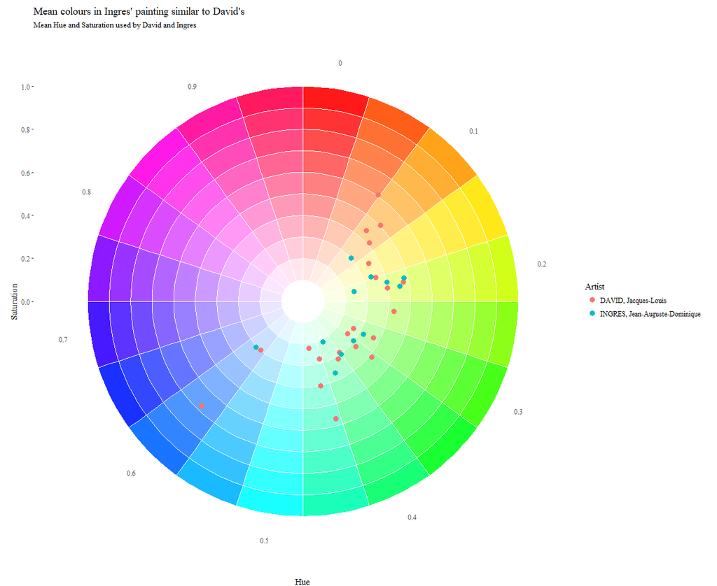

```r
d <- expand.grid(h=seq(0,0.95,0.05), s=seq(0,0.9,0.1))
ggplot() +
  coord_polar(theta="x") +  scale_x_continuous(name="Hue", limits=c(0,1), breaks=seq(0.025,0.925,0.1), labels=seq(0,0.9,0.1)) +
  scale_y_continuous(name="Saturation", breaks=seq(0, 1, 0.2)) +
  scale_fill_identity() +
  geom_rect(data=d, mapping=aes(xmin=h, xmax=h+resolution(h), ymin=s, ymax=s+resolution(s), fill=hsv(h,s)), color="white", size=0.1) + geom_point(aes(x = dav_ing_subset_df$paintings_HSV_mean_hue, y = dav_ing_subset_df$paintings_HSV_mean_sat, colour = dav_ing_subset_df$AUTHOR), data = dav_ing_subset_df, size = 3) + labs(colour = "Artist", title = "Mean colours in Ingres' painting similar to David's", subtitle = "Mean Hue and Saturation used by David and Ingres") +  theme_tufte()
```

# Ingres and David pixel-by-pixel Saturation

In order to do this, the saturation values for each pixel in each painting will be extracted for both Ingres and David.

```r
sublist_dav <- paintings_HSV[grep("DAVID, Jacques-Louis", names(paintings_HSV))]
paintings_dav_sat <- lapply(sublist_dav, '[', 2,,)
dav_sat_vector <- unlist(paintings_dav_sat)
dav_sat_vector_random <- sample(dav_sat_vector, 10000000)
```

```r
paintings_ing <- paintings_HSV[grep("INGRES, Jean-Auguste-Dominique", names(paintings_HSV))]
paintings_ing_sat <- lapply(paintings_ing, '[', 2,,)
ing_sat_vector <- unlist(paintings_ing_sat)
ing_sat_vector_random <- sample(ing_sat_vector, 10000000)
```

Due to computational reasons, 10 million random Saturation values from both Ingres and David’s paintings were extracted.

From the boxplot, it is apparant that the median saturation value for Ingres is less than the median saturation value for David.

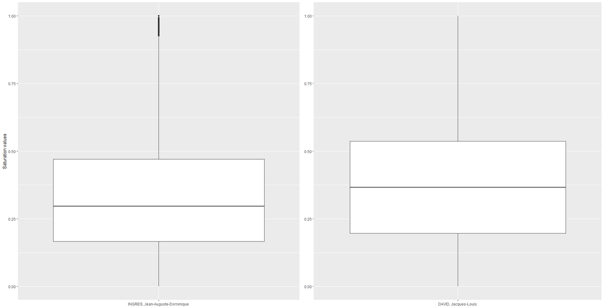

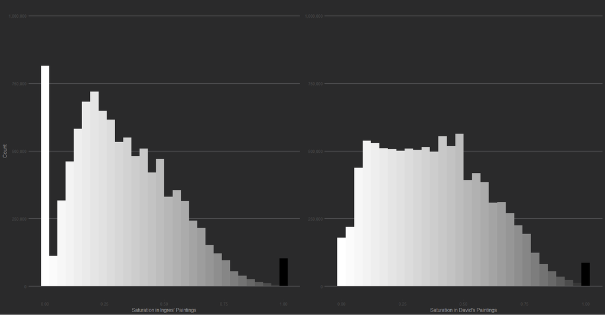

```r
ing_plot <- ggplot() + geom_histogram(aes(x = ing_sat_vector_random), bins = '30', fill = gray.colors(30, start =1, end = 0)) + theme_hc(bgcolor = "darkunica") + scale_y_continuous(labels = comma, limits=c(0, 1000000)) + labs(x = "Saturation in Ingres' Paintings", y = "Count") + theme(legend.position="none")

dav_plot <- ggplot() + geom_histogram(aes(x =dav_sat_vector_random), bins = '30', fill = gray.colors(30, start =1, end = 0)) + theme_hc(bgcolor = "darkunica") + scale_y_continuous(labels = comma, limits=c(0, 1000000))+ labs(x = "Saturation in David's Paintings", y = "Count") + theme(legend.position="none", axis.title.y=element_blank())

grid.arrange(ing_plot, dav_plot, ncol=2)
```